# Election map of Stockholm 2018

Kristofer Svensson

Trying to make a pictore of the election result from the general election 2018.

```r
# Load libraries
library(sf)
library(dplyr)
```

```r
library(magrittr)
library(ggplot2)
```

SF (Simple features), is a library for GIS purposes which can handle most of the types of GIS-files that is supported in software as QGIS and ArcGIS.

As both the election districts data and the Stockholm map is in ESRI shape file format, SF is an exellent choice for working with the files.

dplyr is a standard library for working with tidy data files and comes with the Tidyverse suite of libraries, as is also the case with ggplot2 which is the de fact standard library for making visualisations in R.

```r
election_district_data <- st_read("data/2018_valgeografi_valdistrikt/alla_valdistrikt.shp") %>% st_transform(3011)
```

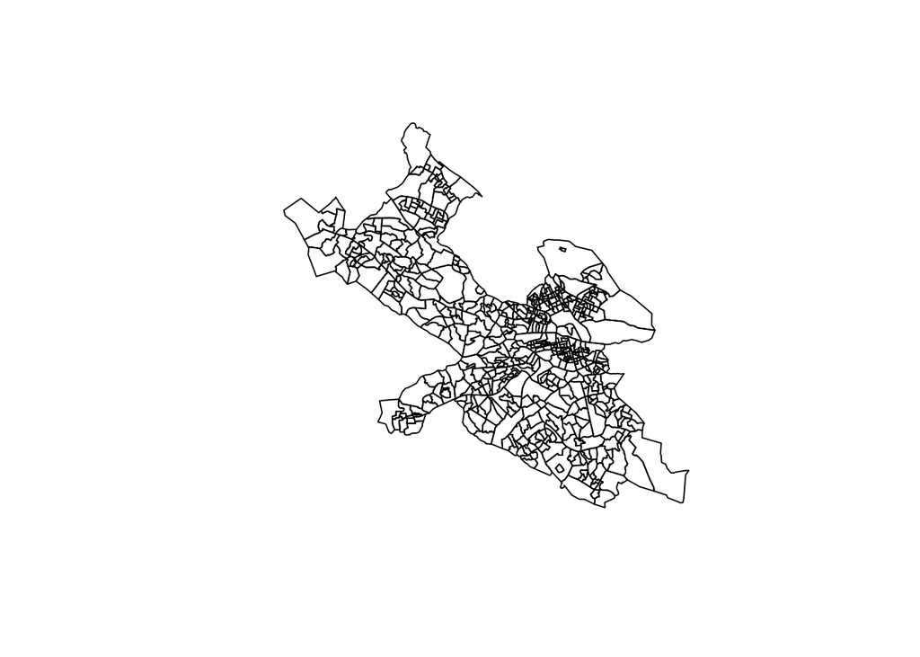

```r
election_district_data %<>%
  filter(KOM == "0180")
plot(election_district_data$geometry)
```

```r
sthlm_land_area <- st_read("data/Stockholm_Taetortskarta_Utskrift_shp/Land_area.shp") %>%
  st_transform(3011) %>%
  st_union() %>%
  st_as_sf()
```

Mycket vatten. Slå ihop med valdistriktkarta för att få bort vatten.

```r
election_district_no_water <- st_intersection(election_district_data, sthlm_land_area)
```

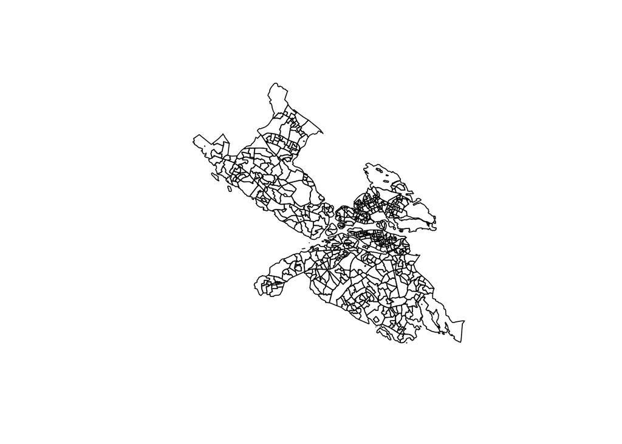

```r
plot(election_district_no_water$geometry)
```

```r
library(readxl) # for reading excel
library(janitor) # for cleaning data
election_data <- read_excel("data/tab5_riksdag.xlsx") %>% clean_names() %>% remove_empty()
```

```
## value for "which" not specified, defaulting to c("rows", "cols")
```

```
## * `` -> ...11
```

```r
head(election_data)
```

```
## # A tibble: 6 × 19
##   valkretskod valkretsnamn   valdistriktskod valdistriktsnamn antal_rostberatti…
##   <chr>       <chr>          <chr>           <chr>                         <dbl>
## 1 02          Stockholms län 01140101        Övra Runby                     1355
## 2 02          Stockholms län 01140102        Mälaren                        1073
## 3 02          Stockholms län 01140120        Edssjön                         830
## 4 02          Stockholms län 01140121        Nedra Runby                    1104
## 5 02          Stockholms län 01140126        Prästgårdsmarken                890
## 6 02          Stockholms län 01140203        Folkparken                     1102
## # … with 14 more variables: antal_rostande <dbl>, andel_rostande <dbl>,
## #   antal_ogiltiga_valsedlar <dbl>, varav_blanka_valsedlar <dbl>,
## #   antal_giltiga_valsedlar <dbl>, m <dbl>, c <dbl>, l <dbl>, kd <dbl>,
## #   mp <dbl>, s <dbl>, v <dbl>, sd <dbl>, ovr <dbl>
```

```r
library(tidyr) # library for making data 'tidy'
election_data <- election_data %>%
  filter(valkretsnamn == "Stockholms kommun") %>%
  pivot_longer(c("m":"ovr"), names_to = "parti", values_to = "resultat")

head(election_data)
```

```
## # A tibble: 6 × 12
##   valkretskod valkretsnamn      valdistriktskod valdistriktsnamn antal_rostberat…
##   <chr>       <chr>             <chr>           <chr>                       <dbl>
## 1 01          Stockholms kommun 01800101        Domkyrko 1 Gaml…             1436
## 2 01          Stockholms kommun 01800101        Domkyrko 1 Gaml…             1436
## 3 01          Stockholms kommun 01800101        Domkyrko 1 Gaml…             1436
## 4 01          Stockholms kommun 01800101        Domkyrko 1 Gaml…             1436
## 5 01          Stockholms kommun 01800101        Domkyrko 1 Gaml…             1436
## 6 01          Stockholms kommun 01800101        Domkyrko 1 Gaml…             1436
## # … with 7 more variables: antal_rostande <dbl>, andel_rostande <dbl>,
## #   antal_ogiltiga_valsedlar <dbl>, varav_blanka_valsedlar <dbl>,
## #   antal_giltiga_valsedlar <dbl>, parti <chr>, resultat <dbl>
```

```r
election_map_result_national <- inner_join(election_district_no_water, election_data, by = c("VD_NAMN" = "valdistriktsnamn"))

head(election_map_result_national)
```

```
## Simple feature collection with 6 features and 25 fields
## Geometry type: POLYGON
## Dimension:     XY
## Bounding box:  xmin: 153209.4 ymin: 6578162 xmax: 153977.1 ymax: 6578467
## Projected CRS: SWEREF99 18 00
##   LAN       LAN_NAMN RVK          RVK_NAMN LND                  LND_NAMN  LVK
## 1  01 Stockholms län  01 Stockholms kommun  01 Stockholms läns landsting 0101
## 2  01 Stockholms län  01 Stockholms kommun  01 Stockholms läns landsting 0101
## 3  01 Stockholms län  01 Stockholms kommun  01 Stockholms läns landsting 0101
## 4  01 Stockholms län  01 Stockholms kommun  01 Stockholms läns landsting 0101
## 5  01 Stockholms län  01 Stockholms kommun  01 Stockholms läns landsting 0101
## 6  01 Stockholms län  01 Stockholms kommun  01 Stockholms läns landsting 0101
##              LVK_NAMN  KOM  NAMN_KOM    KVK            KVK_NAMN       VD
## 1 1 Södermalm-Enskede 0180 Stockholm 018001 1 Södermalm-Enskede 01801301
## 2 1 Södermalm-Enskede 0180 Stockholm 018001 1 Södermalm-Enskede 01801301
```

[output cut: 32 more lines]

```r
election_data_top_national <- election_map_result_national %>%
  group_by(VD_NAMN) %>%
  slice_max(n = 1, order_by = resultat, with_ties = FALSE)

head(election_data_top_national)
```

```
## Simple feature collection with 6 features and 25 fields
## Geometry type: POLYGON
## Dimension:     XY
## Bounding box:  xmin: 152587.2 ymin: 6579820 xmax: 153693.8 ymax: 6580784
## Projected CRS: SWEREF99 18 00
## # A tibble: 6 × 26
## # Groups:   VD_NAMN [6]
##   LAN   LAN_NAMN       RVK   RVK_NAMN LND   LND_NAMN LVK   LVK_NAMN KOM   NAMN_KOM
##   <chr> <chr>          <chr> <chr>    <chr> <chr>    <chr> <chr>    <chr> <chr>
## 1 01    Stockholms län 01    Stockho… 01    Stockho… 0103  3 Norrm… 0180  Stockho…
## 2 01    Stockholms län 01    Stockho… 01    Stockho… 0103  3 Norrm… 0180  Stockho…
## 3 01    Stockholms län 01    Stockho… 01    Stockho… 0103  3 Norrm… 0180  Stockho…
## 4 01    Stockholms län 01    Stockho… 01    Stockho… 0103  3 Norrm… 0180  Stockho…
## 5 01    Stockholms län 01    Stockho… 01    Stockho… 0103  3 Norrm… 0180  Stockho…
## 6 01    Stockholms län 01    Stockho… 01    Stockho… 0103  3 Norrm… 0180  Stockho…
## # … with 16 more variables: KVK <chr>, KVK_NAMN <chr>, VD <chr>, VD_NAMN <chr>,
## #   valkretskod <chr>, valkretsnamn <chr>, valdistriktskod <chr>,
## #   antal_rostberattigade <dbl>, antal_rostande <dbl>, andel_rostande <dbl>,
## #   antal_ogiltiga_valsedlar <dbl>, varav_blanka_valsedlar <dbl>,
## #   antal_giltiga_valsedlar <dbl>, parti <chr>, resultat <dbl>,
## #   geometry <POLYGON [m]>
```

```r
election_data_top_national %>%
  group_by(parti) %>%
  summarise(count = n())
```

[output not shown]

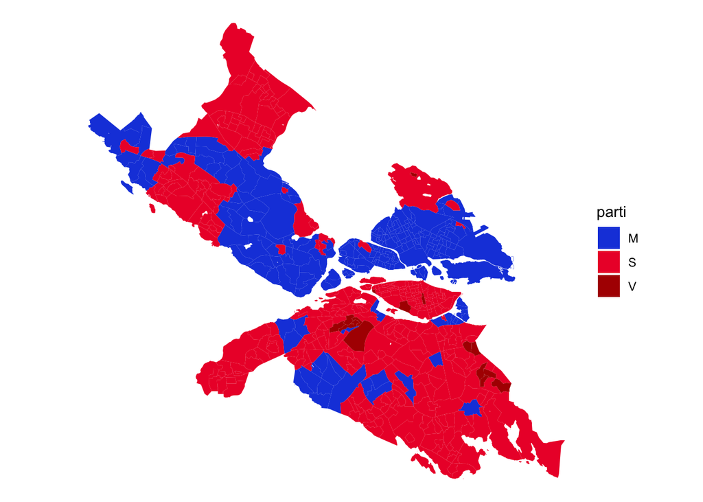

```r
election_data_top_national %>%
  ggplot(
    aes(
      fill = parti
    )
  ) +
  geom_sf(colour = NA) +
  theme_void() +
  scale_fill_manual(
    breaks = c("m", "s", "v"), labels = c("M", "S", "V"), values = c("#1b49dd", "#ed1b34", "#b00000")
  )
```

The map above shows which party was the biggest in each election district. However, it does not show which block of parties was the bigger. To show this we divide the parties inte the two major groups in the Swedish parliament:

```r
election_map_result_national %<>%
  mutate(
    block_h_v = ifelse(parti %in% c("m", "kd", "l", "sd"), "M-KD-L-SD", "S-C-Mp-V")
  )
```

Now we plot this:

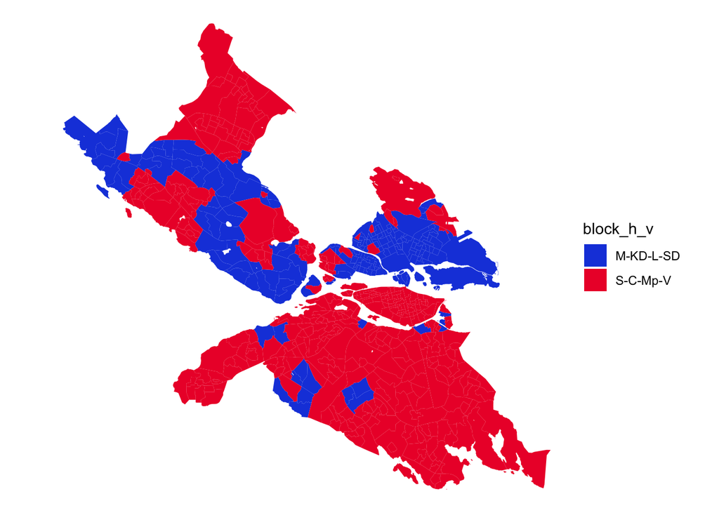

```r
election_map_result_national %>%
  group_by(VD_NAMN, block_h_v) %>%
  summarise(votes = sum(resultat)) %>%
  group_by(VD_NAMN) %>%
  slice_max(n = 1, order_by = votes, with_ties = FALSE) %>%
  ggplot(
    aes(
      fill = block_h_v
    )
  ) +
  geom_sf(colour = NA) +
  theme_void() +
  scale_fill_manual(
    breaks = c("M-KD-L-SD", "S-C-Mp-V"), values = c("#1b49dd", "#ed1b34")
  )
```

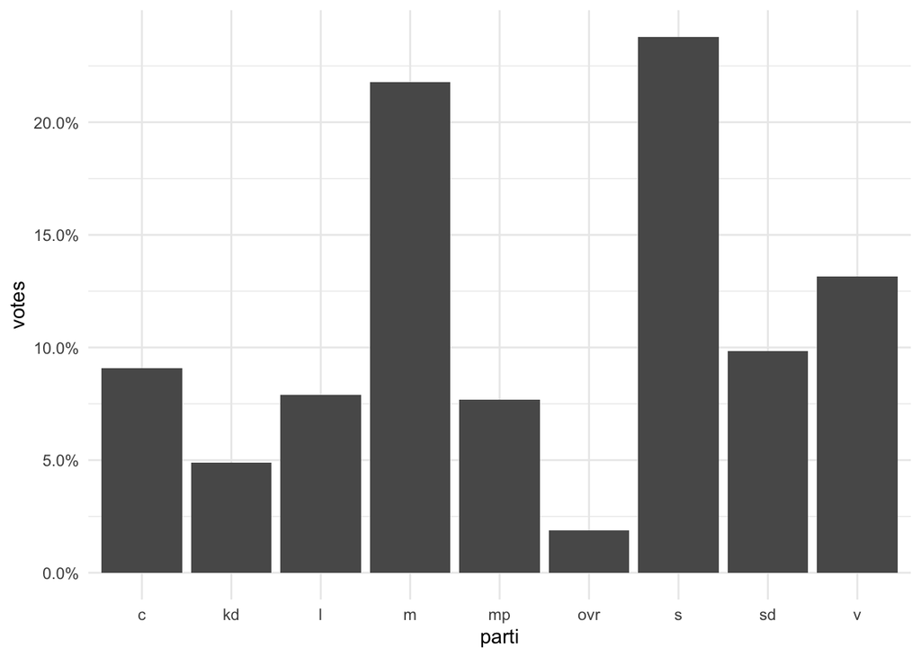

```r
election_map_result_national %>%
  group_by(parti) %>%
  summarise(votes = sum(resultat)/sum(election_map_result_national$resultat)) %>%
  ggplot(
    aes(x = parti, y = votes)
  ) +
  geom_col() +
  theme_minimal() +
  scale_y_continuous(labels = scales::label_percent())
```

It’s hard to visualise this. Dot density map can be the way to go!

```r
st_sample(election_map_result_national, 10)
```

```
## Geometry set for 10 features
## Geometry type: POINT
## Dimension:     XY
## Bounding box:  xmin: 143134.1 ymin: 6575316 xmax: 153924.8 ymax: 6590004
## Projected CRS: SWEREF99 18 00
## First 5 geometries:
```

```
## POINT (143134.1 6582025)
```

```
## POINT (144774.2 6590004)
```

```
## POINT (145687.3 6578876)
```

```
## POINT (144686.2 6575316)
```

```
## POINT (148951.9 6580577)
```